# Advanced Bioinformatics Assignment 2026

# Task 3.11

Transformation of the data using rlog and vst means that the dependence on the hghly expressed genes will be reduced in the model which will allow for easier comparison through graphical methods such as heatmaps and principal component analysis

```r
rld <- rlog(dds)
class(rld)
```

```
## [1] "DESeqTransform"
## attr(,"package")
## [1] "DESeq2"
```

```r
rld_counts <- assay(rld)
class(rld_counts)
```

```
## [1] "matrix" "array"
```

```r
vsd <- varianceStabilizingTransformation(dds)
class(vsd)
```

```
## [1] "DESeqTransform"
## attr(,"package")
## [1] "DESeq2"
```

```r
vsd_counts <- assay(vsd)
class(vsd_counts)
```

```
## [1] "matrix" "array"
```

# Task 3.12

By creating the heatmap in this step we can see how the most highly expressed genes share patterns and whether these cluster together or are clearly separate. This model will look at the top 40 genes which will keep the heatmap tidy whilst also identifying any strong expression patterns in out dataset and samples.

```r
library(DESeq2)
library(pheatmap)

dds <- DESeq(dds)
select <- order(rowMeans(counts(dds, normalized = TRUE)), decreasing = TRUE)[1:40]
head(select)
```

```
## [1] 21373 10174 24719 21374 24718  2808
```

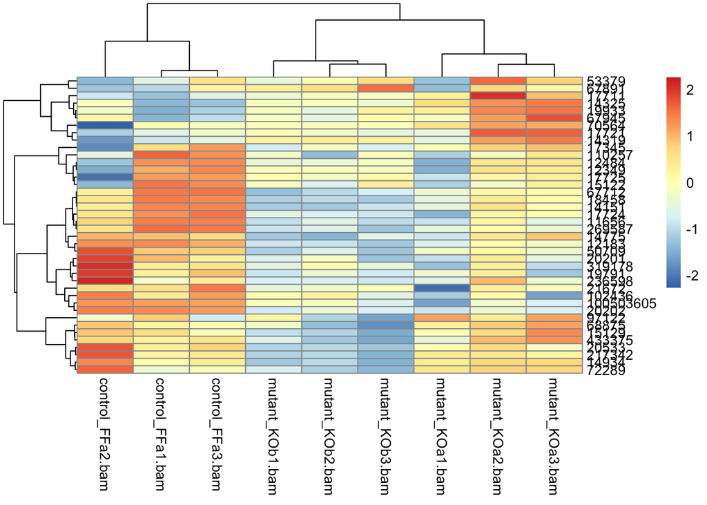

```r
pheatmap(assay(rld)[select, ],
         scale = "row",
         clustering_distance_rows = "correlation",
         clustering_distance_cols = "correlation")
```

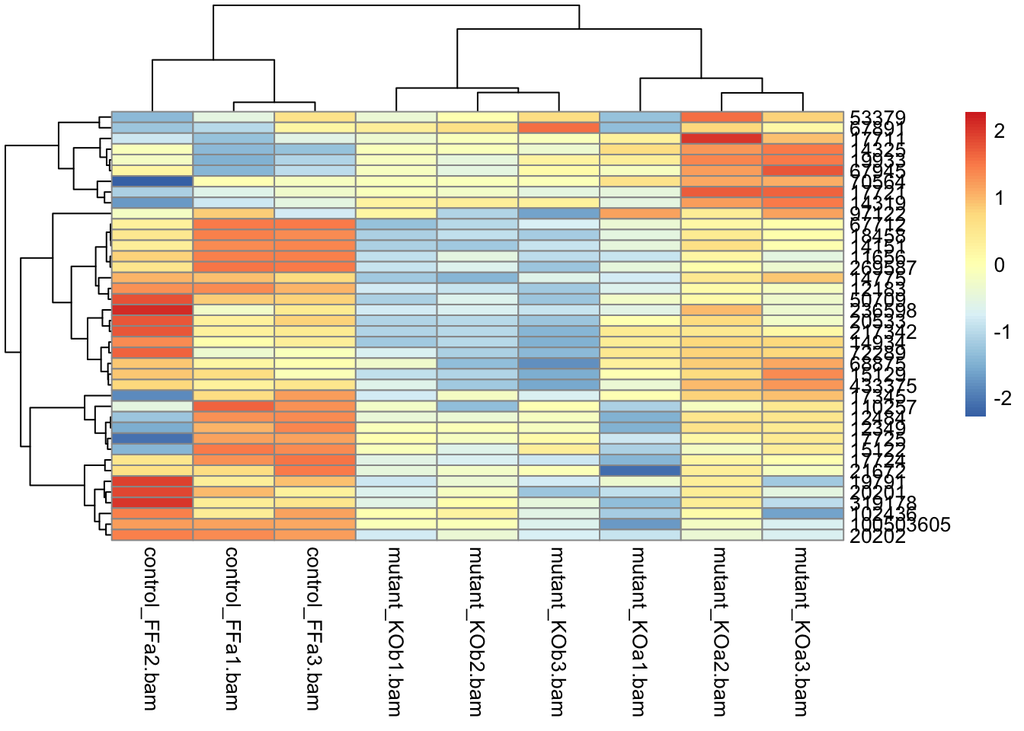

```r
pheatmap(assay(vsd)[select, ],
         scale = "row",
         clustering_distance_rows = "correlation",
         clustering_distance_cols = "correlation")
```

# Task 3.13

The sample distance matric will allow us to look at which of the samples in our dataset are the most similar. It can also help us to identify the outliers in the dataset if there is a sample that consistently falls outside of the normal range of data

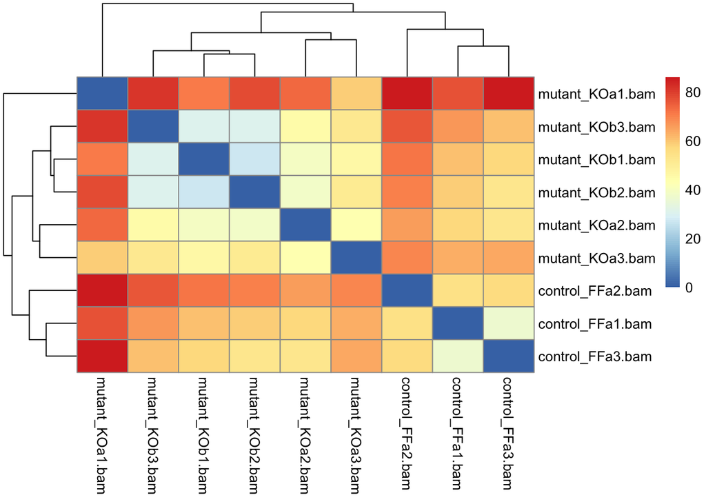

```r
library(pheatmap)

sampleDists <- dist(t(assay(rld)))
sampleDistMatrix <- as.matrix(sampleDists)
rownames(sampleDistMatrix) <- colnames(rld)
colnames(sampleDistMatrix) <- colnames(rld)

pheatmap(sampleDistMatrix, clustering_distance_rows = sampleDists,
         clustering_distance_cols = sampleDists)
```

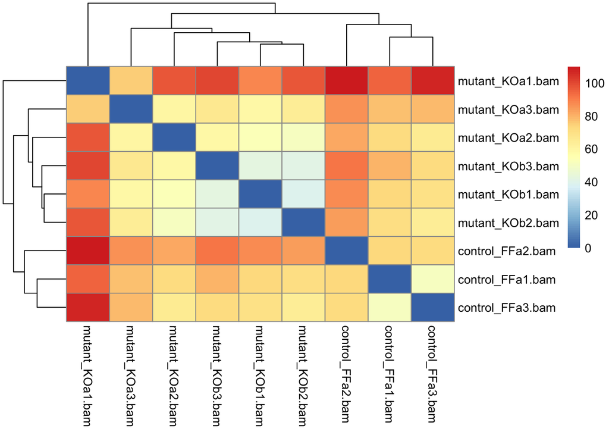

```r
sampleDists_vsd <- dist(t(assay(vsd)))
sampleDistMatrix_vsd <- as.matrix(sampleDists_vsd)
rownames(sampleDistMatrix_vsd) <- colnames(vsd)
colnames(sampleDistMatrix_vsd) <- colnames(vsd)

pheatmap(sampleDistMatrix_vsd, clustering_distance_rows = sampleDists_vsd,
         clustering_distance_cols = sampleDists_vsd)
```

# Task 3.14

```r
library(ggplot2)
pca_rld <- plotPCA(rld, intgroup = "condition", returnData = TRUE)
```

```
## using ntop=500 top features by variance
```

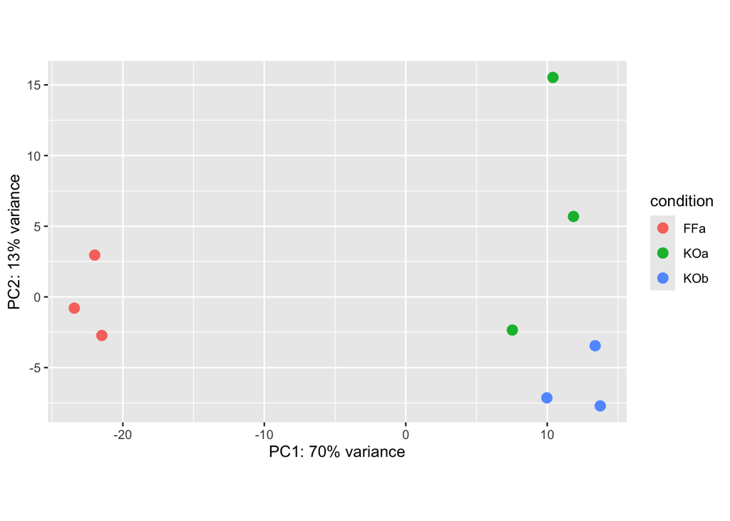

```r
percentVar_rld <- round(100 * attr(pca_rld, "percentVar"))

ggplot(pca_rld, aes(PC1, PC2, color = condition)) +
  geom_point(size = 3) +
  xlab(paste0("PC1: ", percentVar_rld[1], "% variance")) +
  ylab(paste0("PC2: ", percentVar_rld[2], "% variance")) +
  coord_fixed()
```

# Task 3.15 rlog and vst transformations both stabilise variance and will alter the datasets differently depending on hoew many samples there are. From these transformations we can create PCA plots to then compsre the variance in the models which can test our data’s robustness or if one transformation separates between the data points better

```r
pca_vsd <- plotPCA(vsd, intgroup = "condition", returnData = TRUE)
```

```
## using ntop=500 top features by variance
```

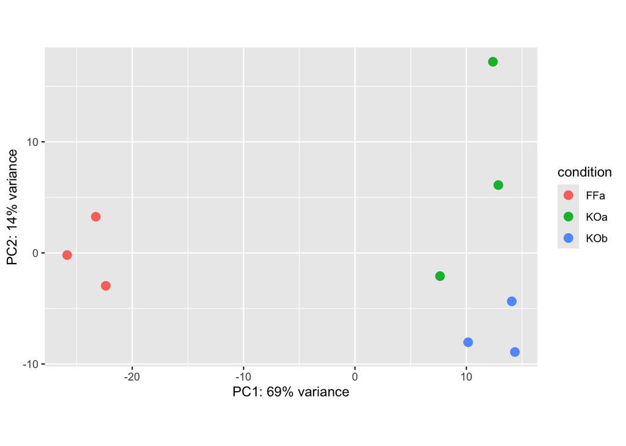

```r
percentVar_vsd <- round(100 * attr(pca_vsd, "percentVar"))

ggplot(pca_vsd, aes(PC1, PC2, color = condition)) +
  geom_point(size = 3) +
  xlab(paste0("PC1: ", percentVar_vsd[1], "% variance")) +
  ylab(paste0("PC2: ", percentVar_vsd[2], "% variance")) +
  coord_fixed()
```